# Exploring Danielson Scores

```r
library(tidyverse)
library(pander)
library(DT)
library(mosaic)
danielson <- read_csv('Danielson_fixed.csv')
```

## Overview

These scores go back to 2020, and cover 35 different classes from 103 different teachers, for a total of 9854 observations from 4049 students.

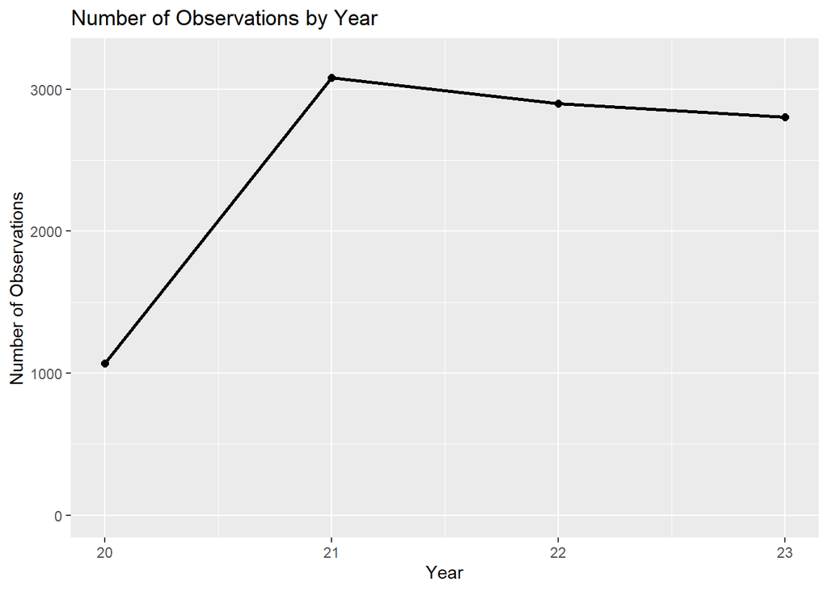

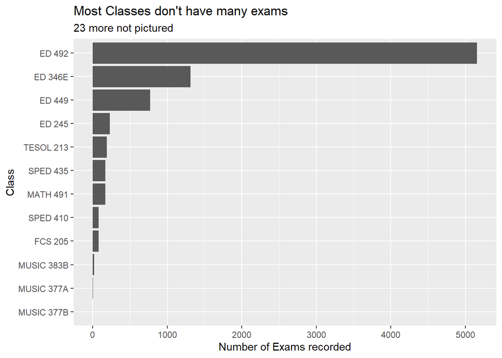

```r
ggplot(danielson %>% mutate(Year=as.integer(str_extract(Semester,'\\d\\d'))),
  aes(Year)) +
    geom_path(stat = 'count',lwd=1) + ylim(c(0,3200)) +
  geom_point(stat='count',size=2) +
  labs(x='Year',y='Number of Observations',title='Number of Observations by Year')
ggplot(danielson %>% summarise(count=n(),.by=Course) %>% head(12),aes(x=count,y=reorder(Course,count))) + geom_col() +
  labs(x='Number of Exams recorded',y='Class',title='Most Classes don\'t have many exams',subtitle='23 more not pictured')
```

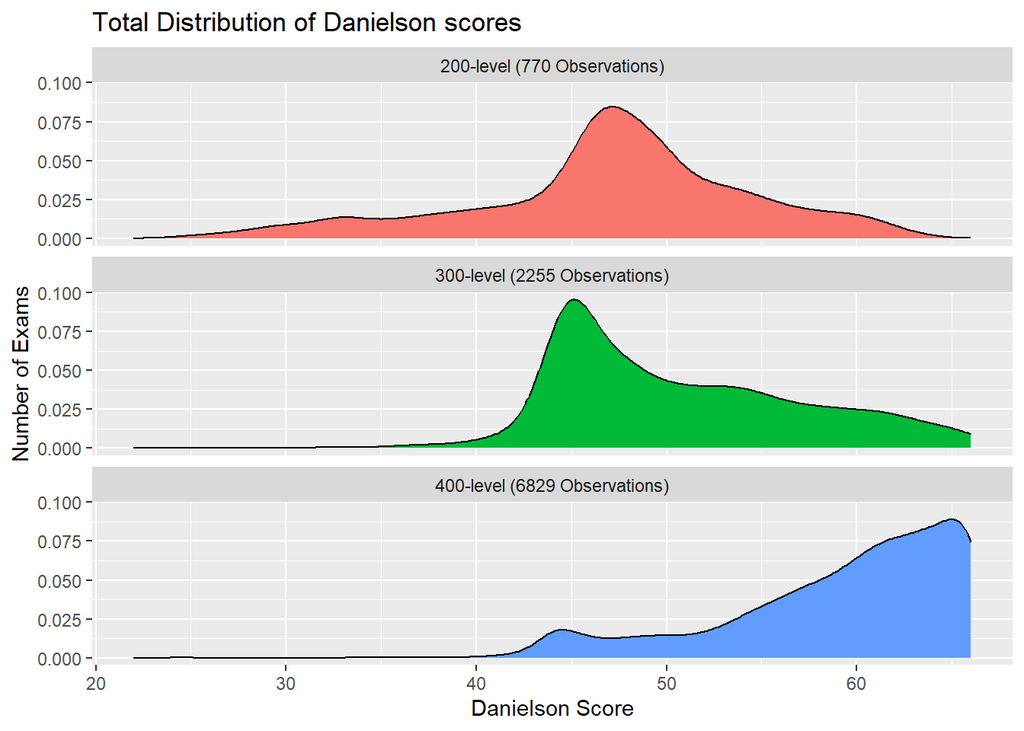

```r
ggplot(danielson %>% mutate(Level = case_when(
      str_detect(Course,'4\\d\\d') ~ '400-level (6829 Observations)',
      str_detect(Course,'3\\d\\d') ~ '300-level (2255 Observations)',
      str_detect(Course,'2\\d\\d') ~ '200-level (770 Observations)')), aes(x=total,group=Level,fill=Level)) +
  geom_density() +
  facet_wrap(~Level,nrow=3) +
  labs(x='Danielson Score',y='Number of Exams',
       title='Total Distribution of Danielson scores') +
  theme(legend.position ='none')
```

```r
pander(favstats(danielson$total))
```

| min | Q1 | median | Q3 | max | mean | sd | n | missing |
| --- | --- | --- | --- | --- | --- | --- | --- | --- |
| 22 | 50 | 58 | 63 | 66 | 56.25 | 7.718 | 9854 | 0 |

### Challenges

There are some challenges as we try to put Danielson scores into our final model of student success:

- Students can get graded multiple times per class (Formative, Midterm, Final). However, not all students have all 3, and some students don’t even have a Final score in our dataset.
- Students get graded on multiple classes through their time.
- Teachers in those classes have their own opinions on how to score, and give different average scores through their history.

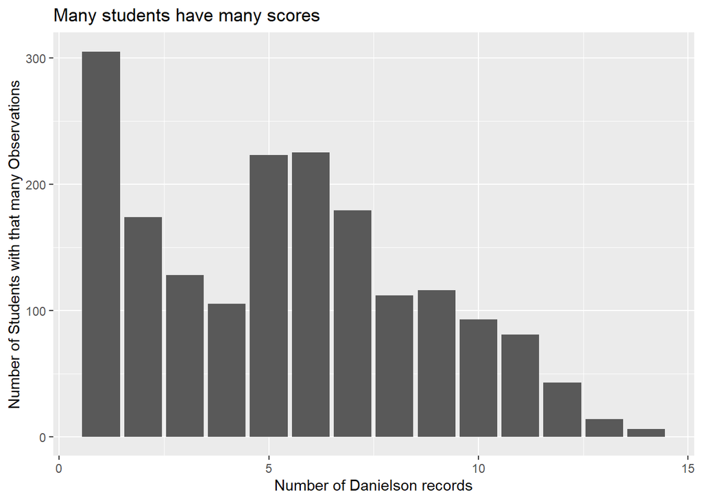

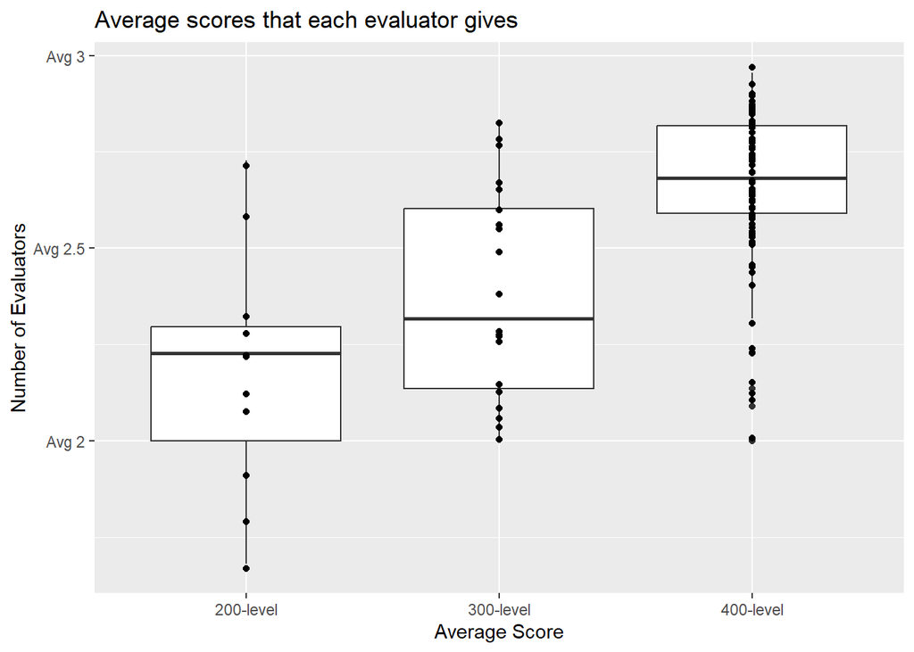

```r
ggplot(danielson %>% filter(!is.na(StudentID)) %>% summarise(num_tests=n(),.by=StudentID),aes(x=num_tests))+
  geom_bar() +
  labs(x='Number of Danielson records',y='Number of Students with that many Observations', title='Many students have many scores')
ggplot(danielson %>% summarise(avg_score=round(mean(total,na.rm=T),0),.by=c(EvaluatorCode,GradeLevel)),
       aes(x=GradeLevel,y=avg_score)) +
  geom_boxplot() +
  geom_jitter(width=0) +
  labs(title='Average scores that each evaluator gives',
       x='Average Score',y='Number of Evaluators') +
  scale_y_continuous(labels=c('Avg 1','Avg 2','Avg 2.5','Avg 3'),breaks=c(22,44,55,66))
```

## How to Consolidate

We want to use Danielson score both as a measure we can predict through early school experience, and as a predictor of post-college teaching success. To do this, we have to summarise these scores into a single value for each student.

**Weighing important Danielson Questions**

Both Idaho and BYU-I’s scoring systems gives equal weight to each question, but that doesn’t necessarily mean each question is equally important for teachers. We’ve re-weighted each of the questions based on personal preference, and we’ll see if this new version is a better predictor than the equal weighting used in classes.

```
1a: Demonstrating knowledge of content and pedagogy (2)
1b: Demonstrating knowledge of students (5)
1c: Setting instructional outcomes (10)
1d: Demonstrate knowledge of resources (1)
1e: Design coherent instruction (1)
1f: Design student assessments (10)
2a: Create an environment of respect and rapport (10)
2b: Establish a culture for learning (10)
2c: Managing classroom procedures (5)
2d: Managing student behavior (5)
2e: Organizing physical space (0)
3a: Communicating with students (2)
3b: Questioning and discussion techniques (2)
3c: Engaging students in learning (5)
3d: Using assessment in instruction (10)
3e: Demonstrate flexibility and responsiveness (2)
4a: Reflecting on teaching (0)
4b: Maintain accurate records (0)
4c: Communicate with families (0)
4d: Participate in PLCs (0)
4e: Grow and develop professionally (0)
4f: Demonstrate professionalism (0)
```

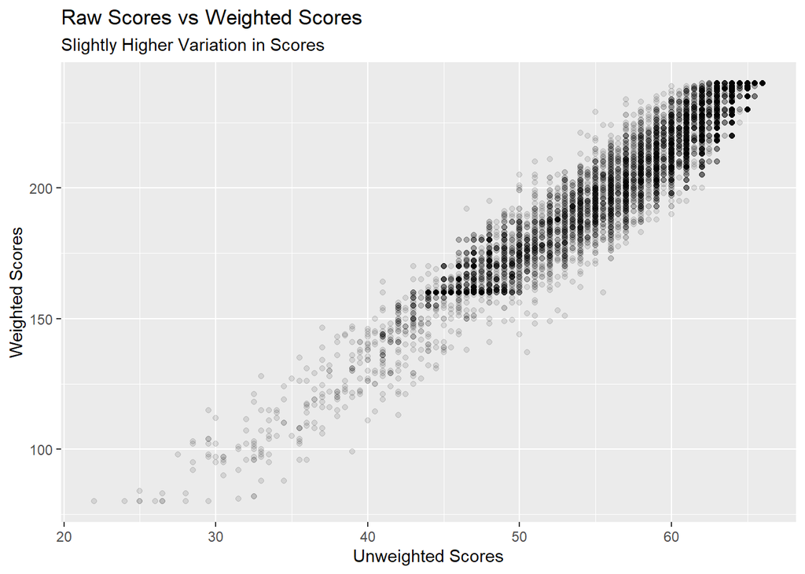

```r
ggplot(danielson,aes(x=total,y=weighted_total)) +
  geom_point(alpha=.1) +
  labs(title='Raw Scores vs Weighted Scores',
       subtitle='Slightly Higher Variation in Scores',
       x='Unweighted Scores',y='Weighted Scores')
```

**Adjusting scores for evaluator & class preferences**

```r
z_danielson <- danielson %>%
  group_by(StudentID, Course) %>%
    slice(1) %>% #Grab only the most important score they have in the class
    ungroup() %>%
    mutate(overallSD = sd(total),
           WoverallSD = sd(weighted_total)) %>%
    group_by(EvaluatorCode,Course) %>%
    mutate(EvalAvg = mean(total,na.rm=TRUE),
           EvalSD = sd(total,na.rm=TRUE),
           EvalSD = replace_na(EvalSD,min(overallSD)),
           EvalSD = ifelse(n()<=5,overallSD,EvalSD),
           WEvalAvg = mean(weighted_total,na.rm=TRUE),
           WEvalSD = sd(weighted_total,na.rm=TRUE),
           WEvalSD = replace_na(WEvalSD,min(overallSD)),
           WEvalSD = ifelse(n()<=5,WoverallSD,WEvalSD)
    ) %>% #When only one teacher, use the SD of all data
    ungroup() %>%
    mutate(z_score = round(ifelse(EvalSD==0,0,(total-EvalAvg)/EvalSD),3),
           weighted_z_score = round(ifelse(WEvalSD==0,0,(weighted_total-WEvalAvg)/WEvalSD),3),
           WDifference=weighted_z_score-z_score) #Catch a class of identical scores
z_danielson %>%
  select(StudentID,Course,total,EvalAvg,EvalSD,z_score) %>%
  head(5) %>%
  pander()
```

| StudentID | Course | total | EvalAvg | EvalSD | z_score |
| --- | --- | --- | --- | --- | --- |
| 3681 | ED 492 | 44 | 44.57 | 6.527 | -0.087 |
| 3681 | HIST 206 | 51 | 49.31 | 4.009 | 0.423 |
| 3681 | HIST 406 | 47 | 50.84 | 4.686 | -0.819 |
| 8027 | ED 346E | 46 | 46.14 | 3.033 | -0.046 |
| 8027 | ED 449 | 66 | 57.94 | 9.394 | 0.858 |

A z_score of 0 means the teacher only graded one person, or that the student matched that average score exactly. We considered grouping evaluations by the evaluator, course *and* the semester students took the class, but that created too many groups and diluted the usefulness of our z-score method.

**Multiple Scores per Class**

If we rank each exam within the class by their priority (1 for Finals, 2 for Midterms, 3 for Formatives), we can grab just the highest-priority score for each student’s class.

```r
ranked<-danielson %>%
  arrange(ranked_test) %>%
  #group_by(StudentID,Course) %>%
  slice(1,.by=c(StudentID,Course)) %>%
  select(StudentID,Course,ranked_test,total)
pander(ranked %>% slice(6,.by=ranked_test))
```

| StudentID | Course | ranked_test | total |
| --- | --- | --- | --- |
| 317624 | ED 492 | 1 | 63 |
| 364938 | ENG 329 | 2 | 55.5 |
| 349351 | SPED 410 | 3 | 62.5 |

Most students do have a final exam recorded, but some that are missing that score will replace it with something else available.

```r
pander(table(ranked$ranked_test))
```

| 1 | 2 | 3 |
| --- | --- | --- |
| 3760 | 39 | 250 |

**Multiple classes**

We can also rank the courses for each student by how comparable the classes are and what level the classes are (and likely how far into their college career students took this class).

1. ED 492
2. Any 400-level
3. ED 346E
4. Any 300-level
5. Any other class

Most education majors take ED 492 and ED 346, so grabbing those classes with standardized curriculums makes comparisons across students easier.

```r
z_person_danielson <- z_danielson %>%
  mutate(ranked_class = case_when(
      #492, any 400-level, 346, any 300-level
      str_detect(Course,'492') ~ '1',
      str_detect(Course,'4\\d\\d') ~ '2',
      str_detect(Course,'346') ~ '3',
      str_detect(Course,'3\\d\\d') ~ '4',
      TRUE ~ '5')) %>%
    arrange(StudentID,ranked_class) %>%
    slice(1, .by=StudentID)
z_person_danielson %>%
  select(StudentID,Course,ranked_class,z_score) %>%
  head(5) %>%
  pander()
```

| StudentID | Course | ranked_class | z_score |
| --- | --- | --- | --- |
| 3681 | ED 492 | 1 | -0.087 |
| 8027 | ED 449 | 2 | 0.858 |
| 14957 | HIST 206 | 5 | 2.044 |
| 18553 | HIST 406 | 2 | 0.568 |
| 18557 | ED 492 | 1 | 0.075 |

## Putting it All Together

Now we have a single value, `weighted_z_score` that captures how each student performed relative to their peers on the most important observation we have access to.

```r
z_person_danielson %>%
  select(StudentID,Course,weighted_z_score) %>%
  sample_n(5) %>%
  pander()
```

| StudentID | Course | weighted_z_score |
| --- | --- | --- |
| 333977 | ED 492 | 0.722 |
| 481193 | ED 492 | -1.858 |
| 458663 | HIST 206 | 0.336 |
| 386769 | ED 492 | -0.608 |
| 331549 | ED 492 | 0.877 |

## Building Potential Y-Variables

But, why stop there? There are other ways we could represent each student’s Danielson performance, and some might be particularly useful.

- We could see their range of scores, and how much they improved
- We can keep just their ED 492 scores, for a perfect comparison between students
- We can take an average of all their scores, not just the one from the most important class
- We might calculate these on the unweighted scores as well

```r
just_492s <- z_danielson %>%
    filter(Course=='ED 492') %>%
    mutate(ED492 = z_score,
           W_ED492 = weighted_z_score) %>%
    select(StudentID,ED492,W_ED492)

other_top_classes <- z_danielson %>%
  mutate(ranked_class = case_when(
    #492, any 400-level, 346, any 300-level
    str_detect(Course,'492') ~ '1',
    str_detect(Course,'4\\d\\d') ~ '2',
    str_detect(Course,'346') ~ '3',
    str_detect(Course,'3\\d\\d') ~ '4',
    TRUE ~ '5')) %>%
  arrange(StudentID,ranked_class) %>%
  slice(1, .by=StudentID) %>%
  summarise(LastClass = mean(z_score,na.rm=T),
            W_LastClass = mean(weighted_z_score,na.rm=T),.by=StudentID)

other_top_classes %>%
  left_join(just_492s,by='StudentID') %>%
  left_join(z_danielson %>%
              summarise(W_Mean_Zscore=mean(z_score,na.rm=T),
                        W_Mean_Zscore = mean(weighted_z_score,na.rm=T), .by=StudentID)
            ,by='StudentID') %>%
  left_join(z_danielson %>%
              summarise(Improvement = round(max(z_score)-min(z_score),3),
                        W_Improvement = round( max(weighted_z_score)-min(weighted_z_score),3),.by=StudentID),
            by='StudentID') %>%
  sample_n(5) %>%
  datatable(options = list(mode = 'multiple', selected = NULL, target = 'row', selectable = NULL))
```

|  | StudentID | LastClass | W_LastClass | ED492 | W_ED492 | W_Mean_Zscore | Improvement | W_Improvement |
| --- | --- | --- | --- | --- | --- | --- | --- | --- |
| 1 | 405983 | -0.604 | -0.838 | -0.604 | -0.838 | 0.1615 | 2.384 | 2.124 |
| 2 | 403018 | -0.3 | -0.209 | -0.3 | -0.209 | -1.142 | 1.369 | 1.866 |
| 3 | 593106 | 0.381 | 0.507 | 0.381 | 0.507 | -0.2035 | 0.812 | 1.29 |
| 4 | 340865 | -1.199 | -1.004 |  |  | -1.004 | 0 | 0 |
| 5 | 408919 | 0.143 | 0.145 |  |  | 0.145 | 0 | 0 |